# Modelling tidal features

Author

Fernando Mayer, Niamh Cahill, Niamh Mimnagh

Published

October 10, 2026

# Data

This analysis investigates how the estimated tidal features vary through time at GalwayPort. The tidal harmonic analysis provides estimates of seven tidal characteristics: Highest Astronomical Tide (HAT), Mean High Water Springs (MHWS), Mean High Water Neaps (MHWN), Mean Sea Level (MSL), Mean Low Water Neaps (MLWN), Mean Low Water Springs (MLWS), and Lowest Astronomical Tide (LAT). Rather than treating these characteristics as fixed quantities over the complete observational record, the preceding analysis estimated them repeatedly using rolling time windows, allowing their temporal behaviour to be examined.

```r
## Packages
library(arrow)
library(tidyverse)
library(patchwork)
library(TideHarmonics)
library(INLA)
here::i_am("index.qmd")
source(here::here("scripts", "_functions.R"))
theme_set(theme_bw() + theme(legend.position = "right", legend.direction = "vertical"))


## Full dataset
fl <- here::here("rds", sprintf("features-%s.rds", params$station))
da <- readRDS(fl)

## Set ther levels for constituents
const_levels <- c("HAT","MHWS", "MHWN", "MSL", "MLWN", "MLWS","LAT")
## Select the windown interval
ws <- "y_3"
## Define years to predict
yrs <- range(da$year_mid) + c(-10, 10)
yrs_seq <- seq(yrs[1], yrs[2])

## Split by constituent and create a list
db <- da |>
    filter(window_size == ws) |>
    split(~constituent)

## Arrange and complete with more years
db <- imap(db, \(x, nm) {
    x |>
        arrange(year_mid) |>
        complete(year_mid = yrs_seq, fill = list(constituent = nm)) |>
        mutate(constituent = fct_relevel(constituent, const_levels),
            id = seq_along(year_mid), id2 = id, id3 = id)
})
```

# Exploratory analysis

## Time series

The following figure shows the 3-year rolling-window estimates of the seven tidal features at Galway Port from 2009 to 2022. Each point represents the tidal characteristic estimated from a three-year period, positioned at the midpoint year of that window.

The tidal features show clear separation, ranging from HAT at approximately 3 m OD Malin to LAT at approximately −3 m OD Malin, with MSL remaining close to zero.

The upper tidal levels, particularly HAT and MHWS, generally decline from the earlier part of the series before becoming comparatively stable in the later years. A corresponding change can be seen in the lower tidal levels: MLWS and LAT become less negative through the middle of the record, indicating some narrowing of the tidal range. MHWN and MLWN show smaller changes, while MSL exhibits only modest fluctuations around a relatively stable level.

There also appears to be temporal dependence in the trajectories, with neighbouring rolling-window estimates generally similar to one another rather than fluctuating independently. Some of this smoothness is expected because consecutive 3-year windows overlap and share two years of observations. Nevertheless, the presence of gradual changes through time motivates considering models that can represent both systematic trends and additional temporal structure.

Overall, this exploratory analysis suggests that the tidal features are not necessarily well represented by a single constant value through time, while the nature and magnitude of the temporal variation differ between features.

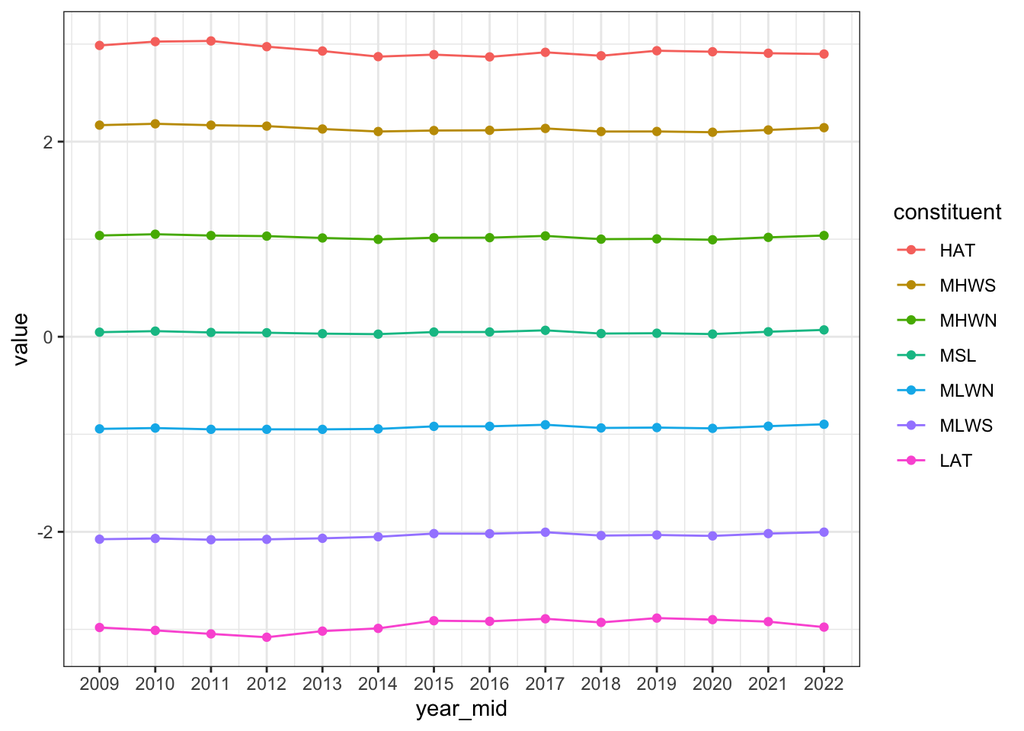

```r
db |>
    bind_rows() |>
    filter(!is.na(value)) |>
    ggplot(aes(x = year_mid, y = value, color = constituent)) +
    geom_line() +
    geom_point() +
    scale_x_continuous(breaks = scales::pretty_breaks(n = 20))
```

# Models

A set of twelve temporal models is fitted to each tidal feature. The models differ in whether they include a temporal trend and in the structure used to represent additional temporal variation. This allows models ranging from a simple constant mean to models containing a deterministic trend together with structured and/or unstructured temporal effects to be compared.

The components used in the models are:

- **Intercept (`1`)**: represents the overall mean level of the tidal feature across the study period.
- **Trend (`id`)**: represents a linear change in the tidal feature through time.
- **IID effect (`f(id2, model = "iid")`)**: represents unstructured temporal variability. Values for different time points are treated as independent, allowing individual years to deviate from the overall mean or trend without assuming temporal dependence between those deviations.
- **AR(1) effect (`f(id3, model = "ar1")`)**: represents temporally correlated variation using a first-order autoregressive process. Values at neighbouring time points are allowed to be more similar, with the temporal dependence decreasing as the separation between time points increases.
- **RW1 effect (`f(id3, model = "rw1")`)**: represents smoothly varying temporal change using a first-order random walk. Consecutive temporal effects are encouraged to be similar, allowing the underlying level to evolve gradually through time.

The twelve candidate models are:

| Model | Formula | Description |
| --- | --- | --- |
| **m1: Intercept only** | `value ~ 1` | Assumes that the tidal feature has a constant mean through time, with no additional temporal structure. |
| **m2: Intercept + IID** | `value ~ 1 + f(id2, model = "iid")` | Assumes a constant overall mean while allowing independent year-to-year deviations from that mean. |
| **m3: Intercept + AR(1)** | `value ~ 1 + f(id3, model = "ar1")` | Assumes a constant overall mean with temporally correlated deviations, so neighbouring time points can have similar values. |
| **m4: Intercept + RW1** | `value ~ 1 + f(id3, model = "rw1")` | Assumes a constant overall mean together with a smoothly evolving temporal effect represented by a first-order random walk. |
| **m5: Intercept + IID + AR(1)** | `value ~ 1 + f(id2, model = "iid") + f(id3, model = "ar1")` | Combines unstructured temporal variability with temporally correlated variation around a constant overall mean. |
| **m6: Intercept + IID + RW1** | `value ~ 1 + f(id2, model = "iid") + f(id3, model = "rw1")` | Combines independent year-to-year variability with a smoothly evolving temporal component around a constant overall mean. |
| **m7: Linear trend** | `value ~ 1 + id` | Includes a linear temporal trend, allowing the expected tidal feature to systematically increase or decrease through time. |
| **m8: Trend + IID** | `value ~ 1 + id + f(id2, model = "iid")` | Includes a linear temporal trend together with independent deviations around that trend. |
| **m9: Trend + AR(1)** | `value ~ 1 + id + f(id3, model = "ar1")` | Includes a linear temporal trend together with temporally correlated deviations around the trend. |
| **m10: Trend + RW1** | `value ~ 1 + id + f(id3, model = "rw1")` | Includes a linear temporal trend together with additional smoothly varying temporal change represented by a first-order random walk. |
| **m11: Trend + IID + AR(1)** | `value ~ 1 + id + f(id2, model = "iid") + f(id3, model = "ar1")` | Includes a linear trend, independent temporal variability, and temporally correlated variability. |
| **m12: Trend + IID + RW1** | `value ~ 1 + id + f(id2, model = "iid") + f(id3, model = "rw1")` | Includes a linear trend, independent temporal variability, and a smoothly evolving temporal component. |

Together, these models allow several possible forms of temporal behaviour to be considered. Models m1–m6 assume no systematic linear trend, whereas models m7–m12 explicitly include a linear trend. Within each group, the models progressively allow for unstructured temporal variation (IID), temporally correlated variation (AR(1)), smoothly evolving temporal variation (RW1), or combinations of these components.

```r
## Define formulas
form <- gen_model_formulas()
form_levels <- names(form)

## List to hold model results
res <- vector(mode = "list", length = length(const_levels))
names(res) <- const_levels
res <- map(res, \(x) {
    out <- vector(mode = "list", length = length(form))
    names(out) <- names(form)
    out
})

## INLA settings and model run
cc <- list(cpo = TRUE, waic = TRUE, dic = TRUE, config = TRUE)
fl <- sprintf("rds/tide-models-%s-all.rds", params$station)
if(!file.exists(fl)) {
    for(i in seq_along(res)) {
        for(j in seq_along(res[[i]])) {
            dc <- db[[i]] # Change data
            res[[i]][[j]] <- inla(formula = form[[j]],
                family = "gaussian", data = dc,
                control.compute = cc)
        }
    }
    saveRDS(res, fl)
} else {
    res <- readRDS(fl)
}
```

# Results

**HAT**

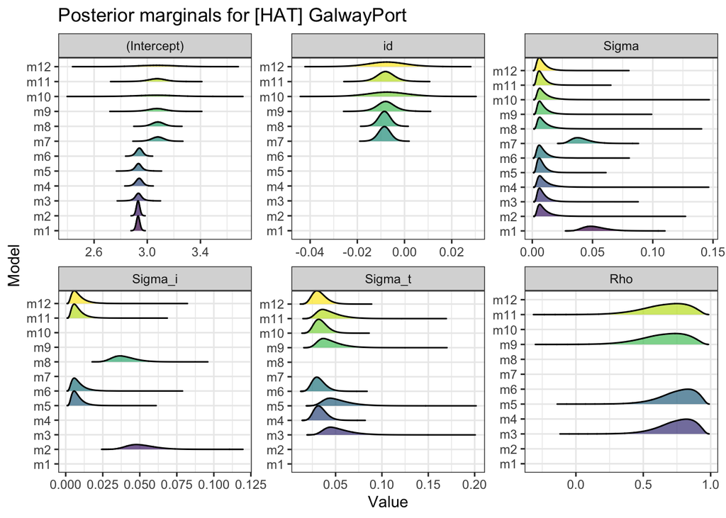

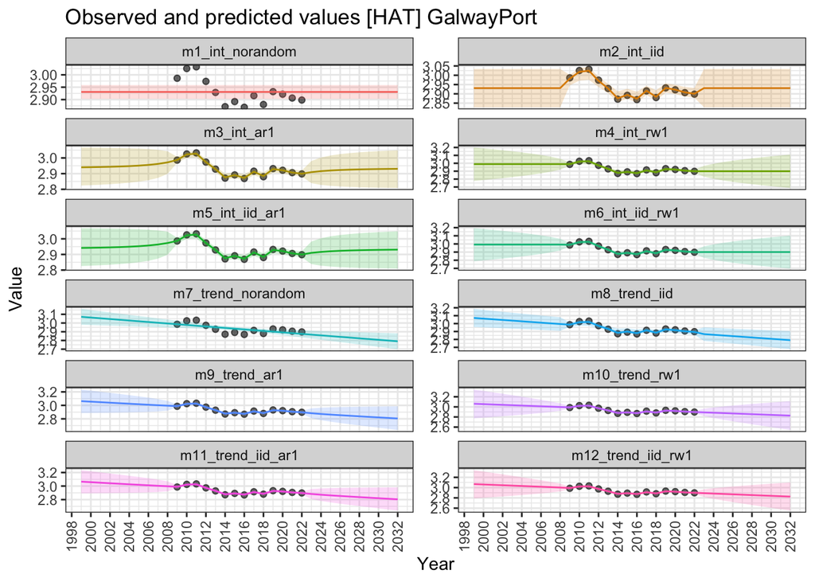

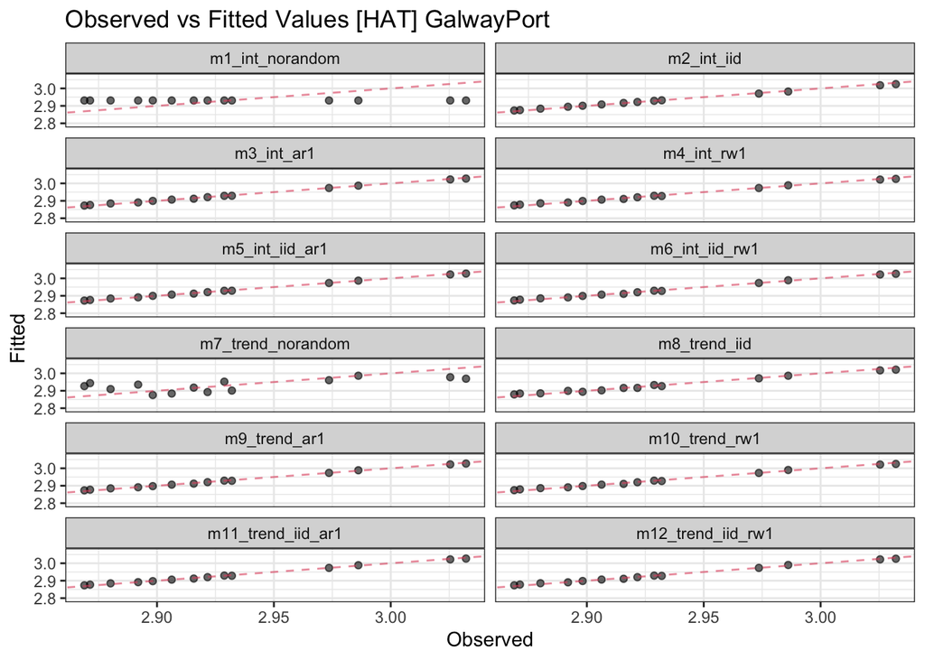

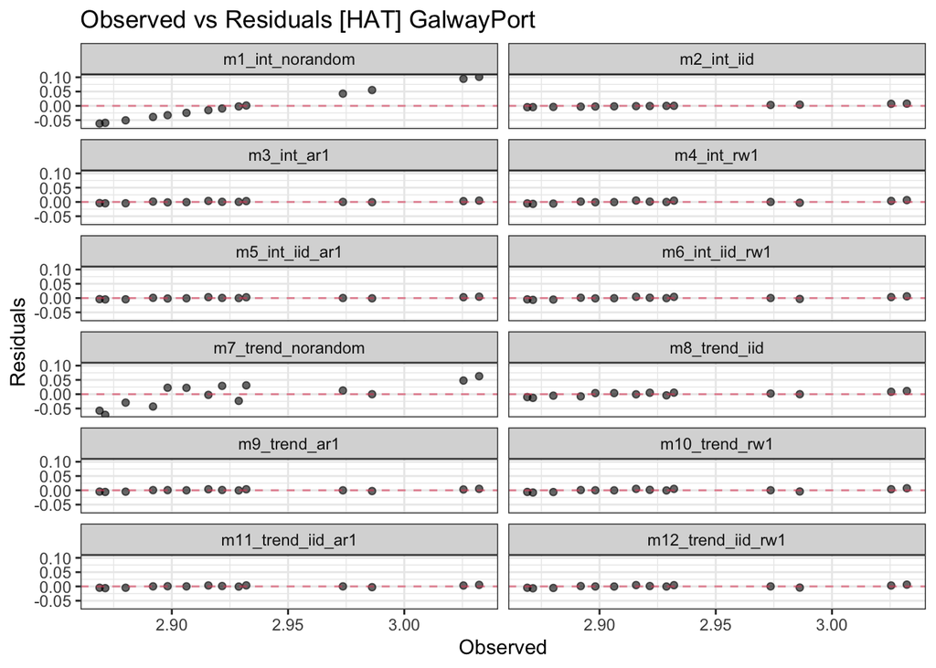

```r
show_temporal_results(
    "HAT",
    res,
    db
)
```

### Posterior Marginal Distributions

The posterior marginal distributions summarise the uncertainty associated with the parameters included across the candidate models. The intercept represents the underlying level of the tidal feature, while id describes the estimated linear temporal trend for models that include one. The remaining panels describe the additional temporal variability: Sigma_i corresponds to the magnitude of the IID component, Sigma_t to the structured temporal component, and Rho to the temporal correlation parameter for models containing an AR(1) effect. Sigma represents the residual observation-level variability.

For HAT, the posterior distributions for the linear trend are centred predominantly on negative values, suggesting a tendency for HAT to decrease through the observed period. This is consistent with the exploratory time series, where HAT is generally higher in the earlier rolling windows and lower in the later part of the record. There is, however, uncertainty around the magnitude of this trend, and the extent to which it provides an adequate description of the temporal behaviour should be considered alongside the alternative models.

The AR(1) models show posterior distributions for Rho concentrated towards relatively high positive values, indicating temporal dependence where this component is included.

The posterior distributions for the IID and structured temporal standard deviations also provide information about the amount of additional variability remaining after accounting for the overall mean or trend. Models containing a linear trend generally appear to leave relatively little residual variation compared with some of the simpler models, suggesting that systematic temporal change explains part of the variation in HAT.

### Observed and Predicted Values

This figure compares the observed HAT estimates for Galway Port with the fitted and predicted values from all twelve candidate temporal models. Observations are available for the midpoint years of the 3-year rolling windows, while the fitted models are extended beyond the observed period to illustrate their implied temporal behaviour. The shaded bands represent uncertainty around the fitted and predicted trajectories.

Models incorporating a structured temporal component provide a much closer representation of the observed series. In particular, the AR(1) and RW1 models (m3–m6) capture the initial higher HAT values, the decline into the middle of the record, and the subsequent smaller fluctuations around approximately 2.9 m. The fitted trajectories closely follow the observations during the period for which data are available.

The models containing a linear temporal trend (m7–m12) consistently estimate an overall decline in HAT through time. The simple trend model, m7, represents this as a steady decrease across the entire period.

An important difference between the models becomes apparent when considering extrapolation beyond the observed period. Models dominated by a linear trend continue the estimated decline into the future, whereas models based on AR(1) or RW1 temporal effects tend to stabilise or revert towards the estimated underlying level. The uncertainty intervals also widen considerably outside the observed period, emphasising the increased uncertainty in predictions for years far from the available observations.

Overall, the figure indicates that HAT exhibits temporal structure that is not adequately represented by a constant mean alone. Both an overall declining tendency and shorter-term temporal variation are evident.

### Observed vs Fitted Values

This figure compares the observed HAT estimates with the corresponding fitted values from each of the twelve models. The dashed diagonal line represents perfect agreement between observed and fitted values, so models whose points lie close to this line provide a better in-sample representation of the observed temporal variation.

A larger improvement is evident for models containing AR(1) or RW1 temporal effects. Models m3–m6 and m9–m12 have fitted values that lie much closer to the 1:1 line across the full observed range. The RW1 models in particular appear to reproduce the observations extremely closely.

### Observed vs Residuals

This figure examines the residuals from each of the candidate models for HAT at Galway Port. Residuals represent the difference between the observed and fitted HAT values, with the dashed horizontal line at zero indicating perfect agreement. A well-fitting model should generally produce small residuals distributed around zero without a clear relationship with the observed values.

In contrast, models containing AR(1) or RW1 temporal effects produce residuals that are very small and concentrated close to zero. This is particularly true for m3–m6 and m9–m12. There is also substantially less evidence of a systematic relationship between the residuals and the magnitude of the observed HAT values, indicating that these models are better able to represent the variation within the observed period.

**MHWS**

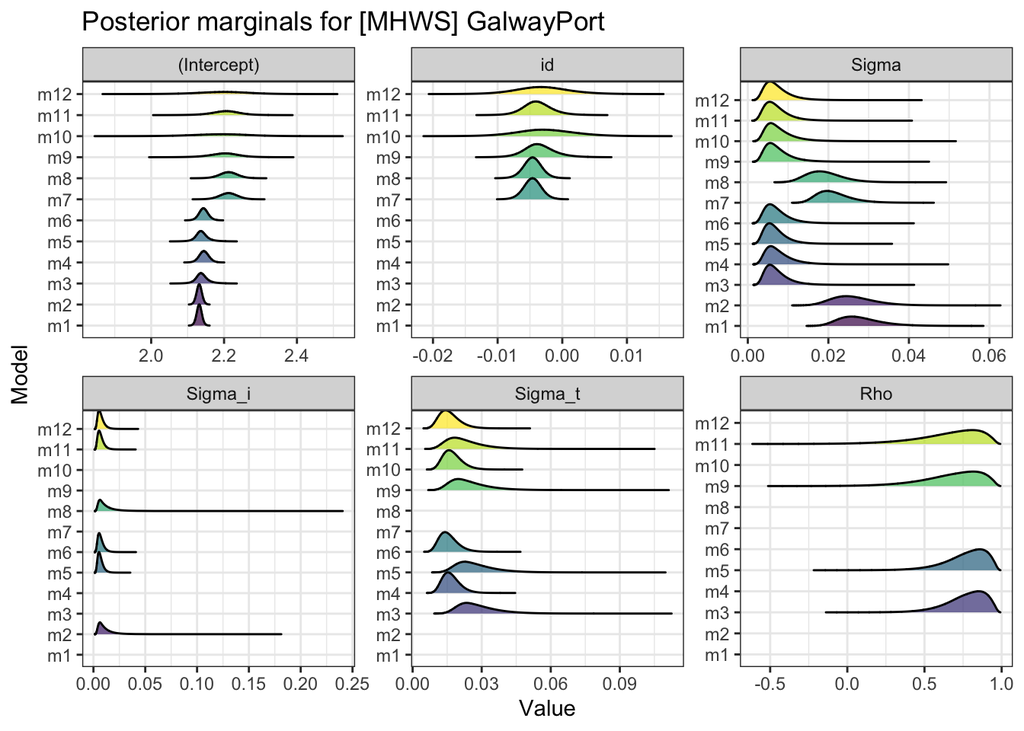

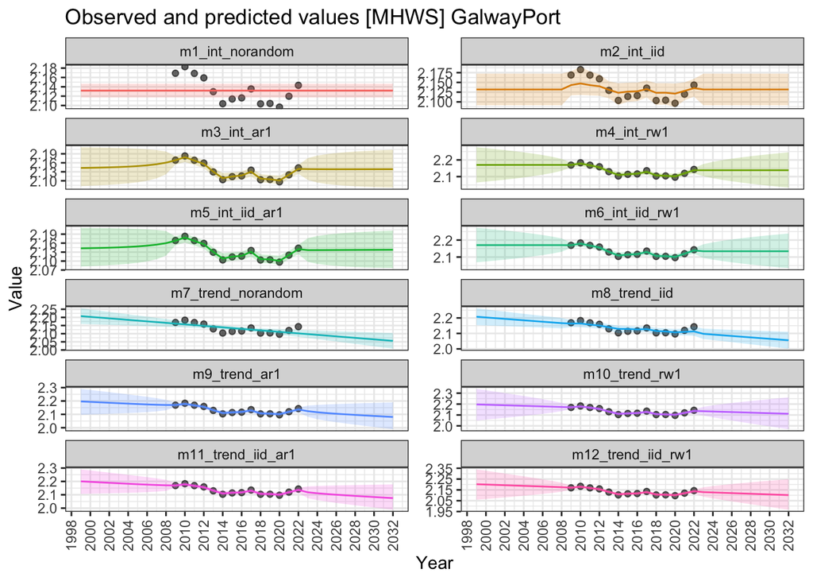

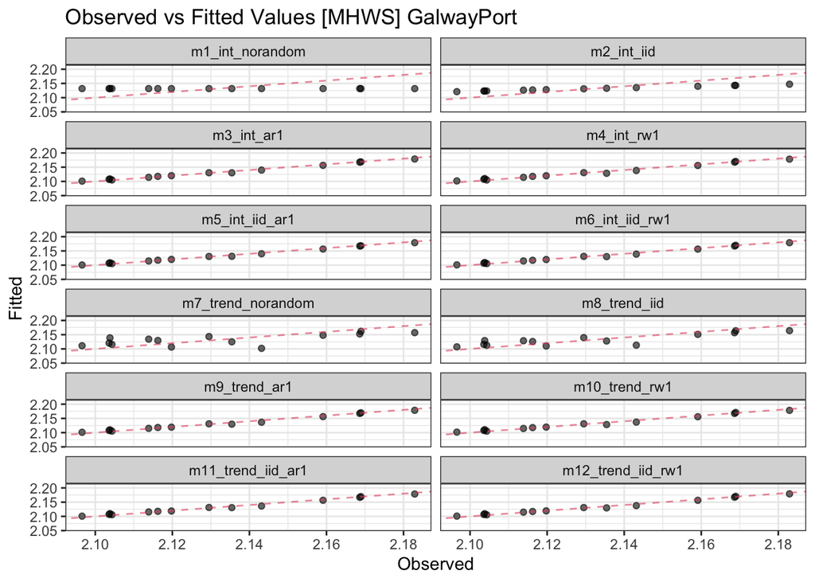

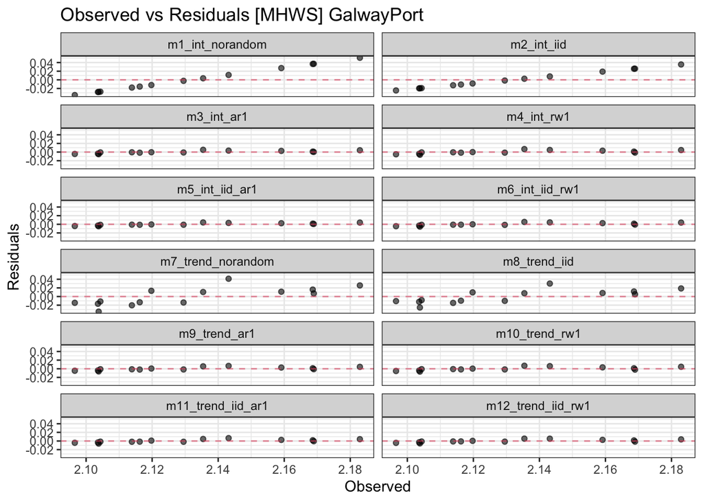

```r
show_temporal_results(
    "MHWS",
    res,
    db
)
```

**MHWN**

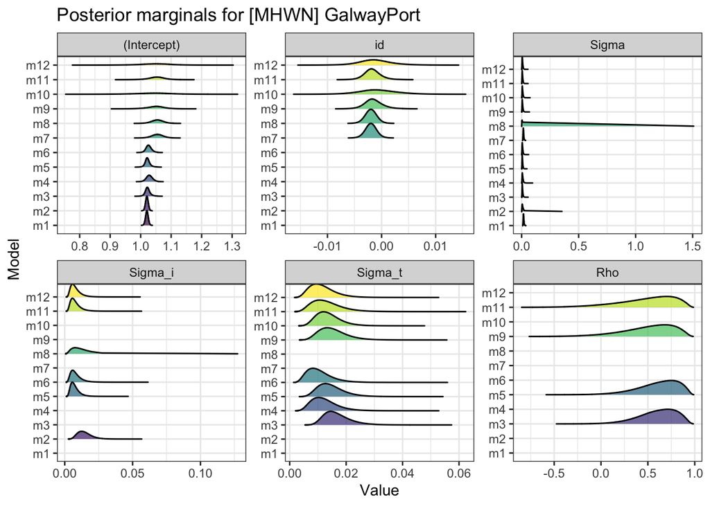

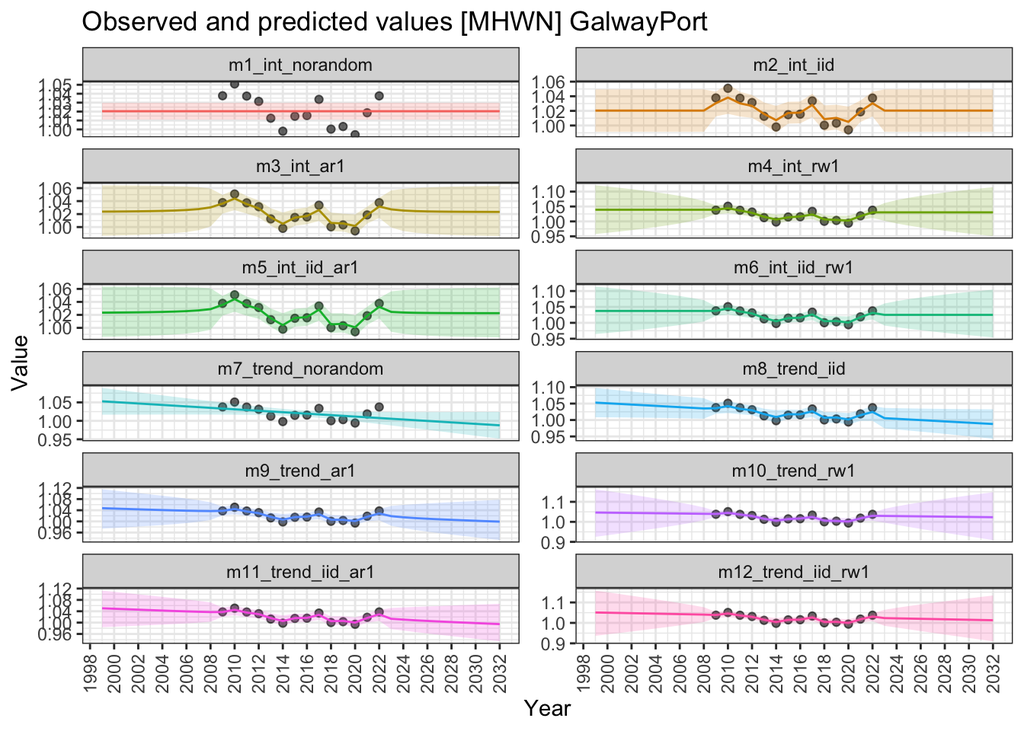

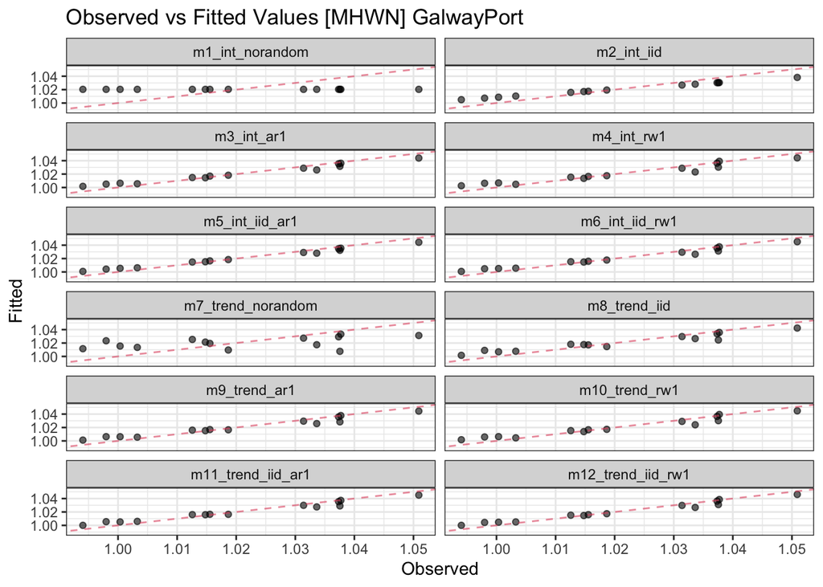

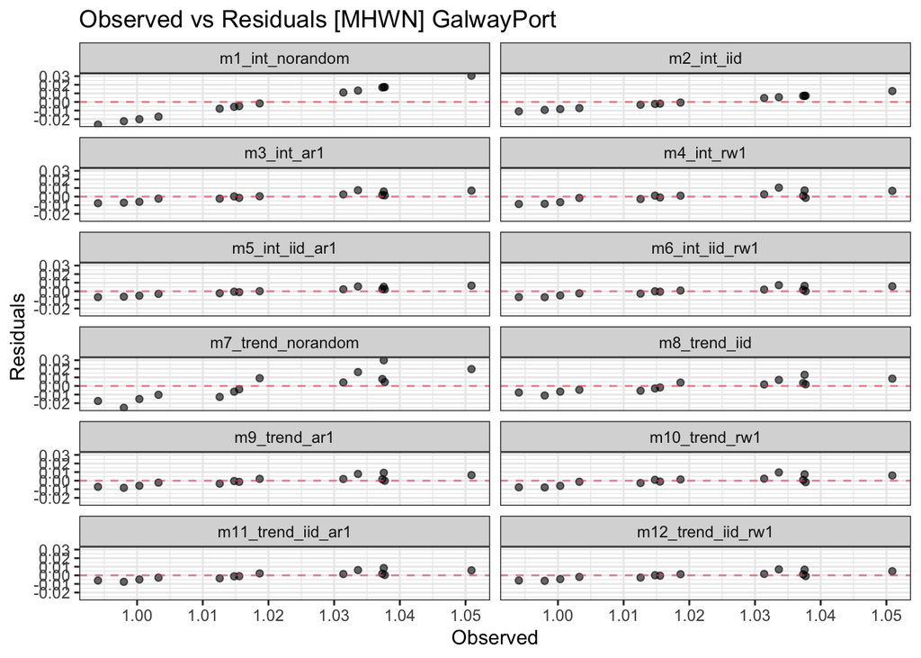

```r
show_temporal_results(
    "MHWN",
    res,
    db
)
```

**MSL**

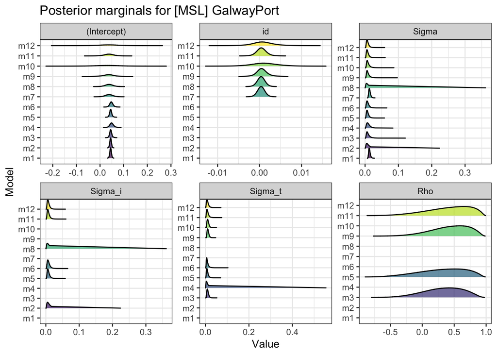

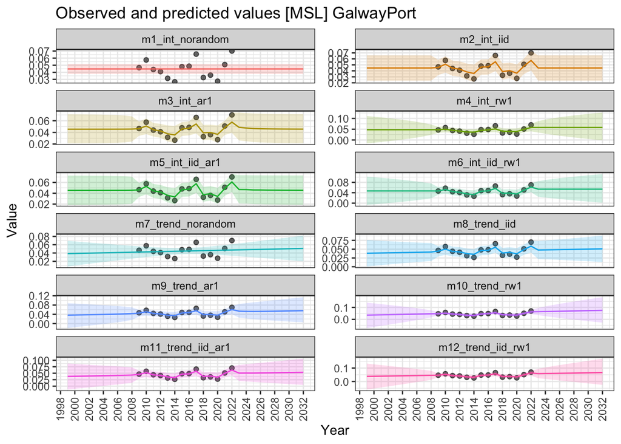

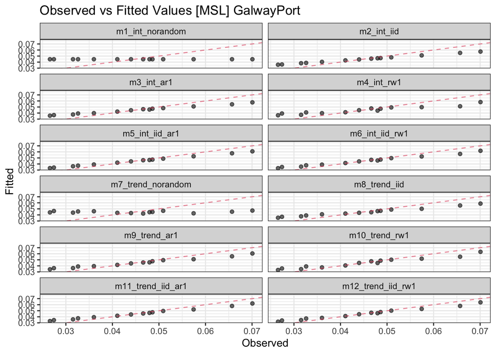

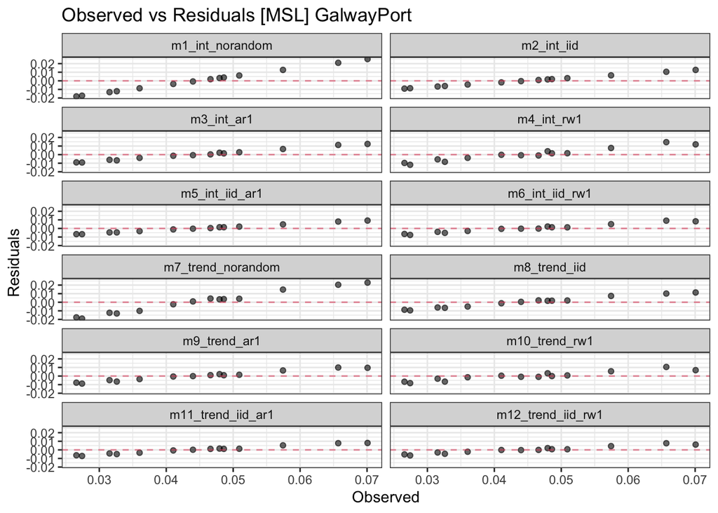

```r
show_temporal_results(
    "MSL",
    res,
    db
)
```

**MLWN**

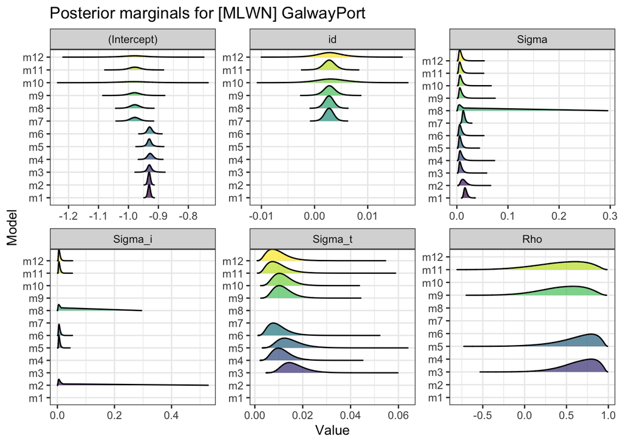

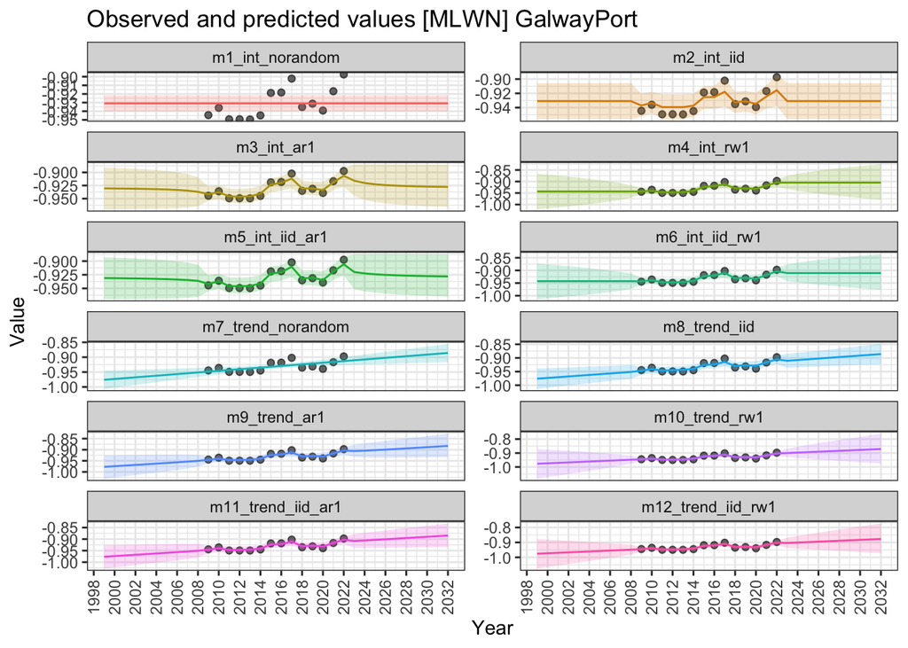

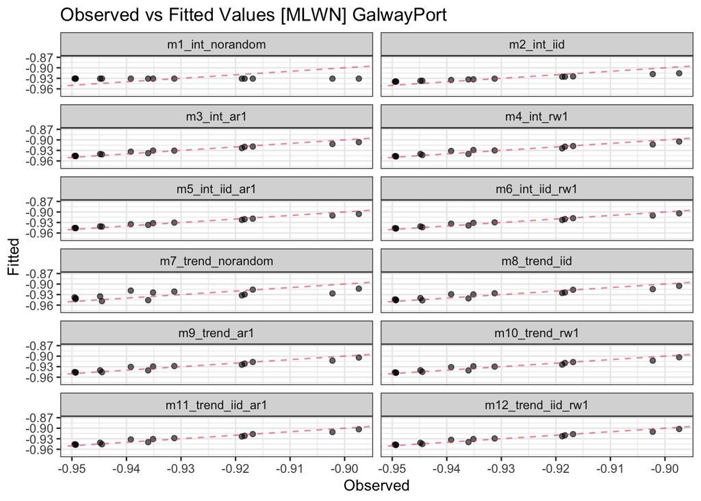

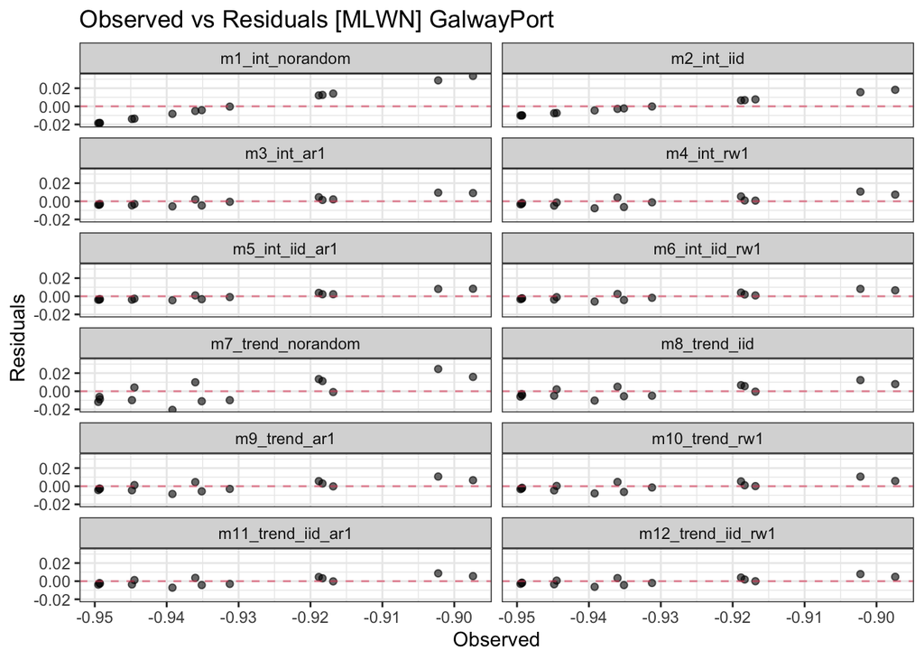

```r
show_temporal_results(
    "MLWN",
    res,
    db
)
```

**MLWS**

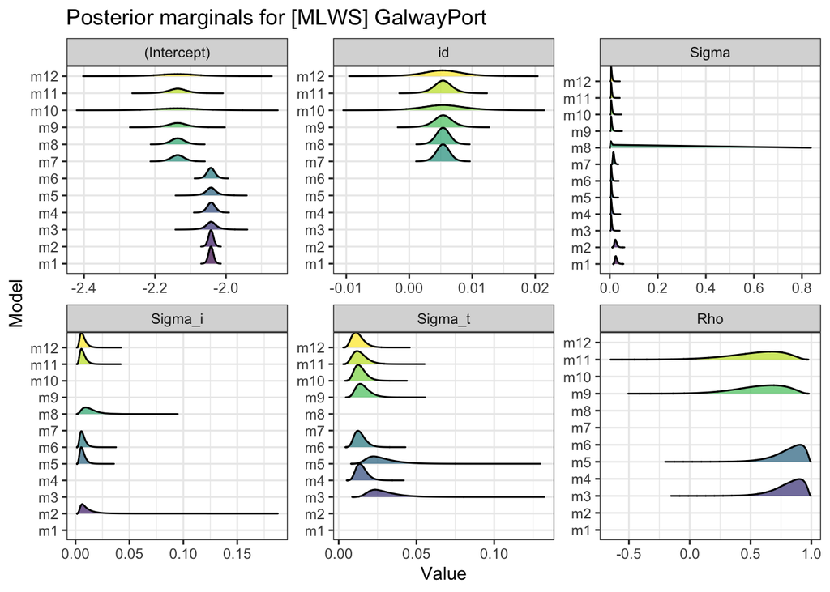

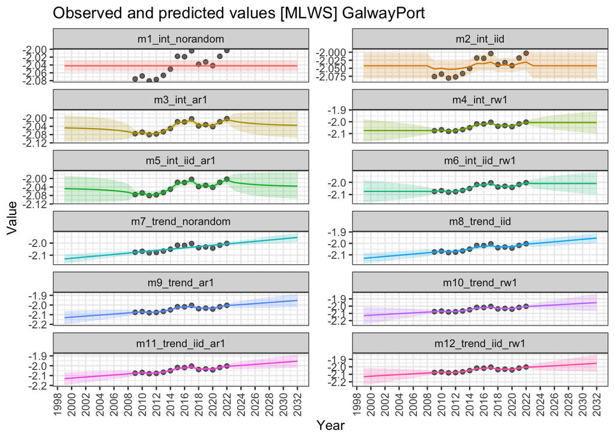

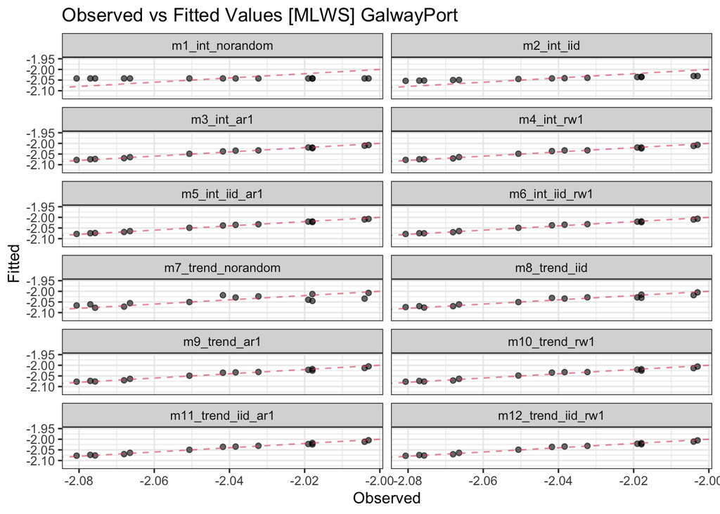

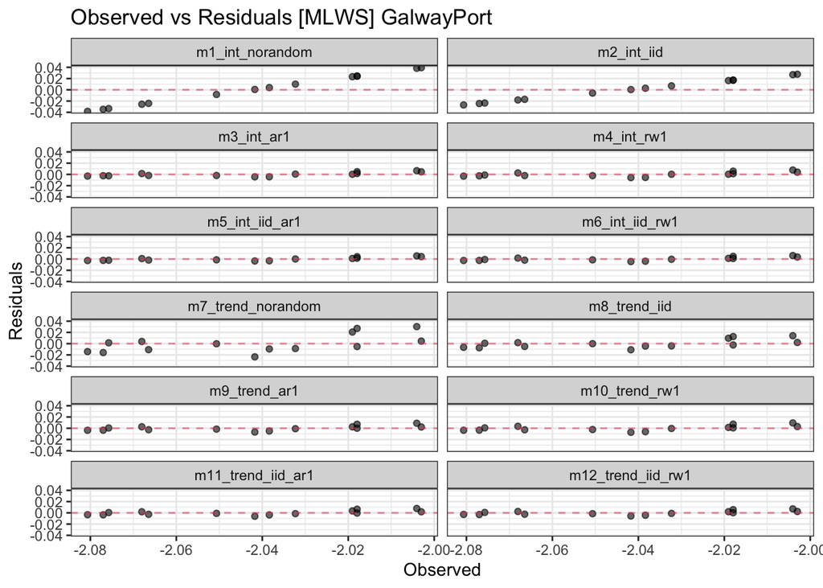

```r
show_temporal_results(
    "MLWS",
    res,
    db
)
```

**LAT**

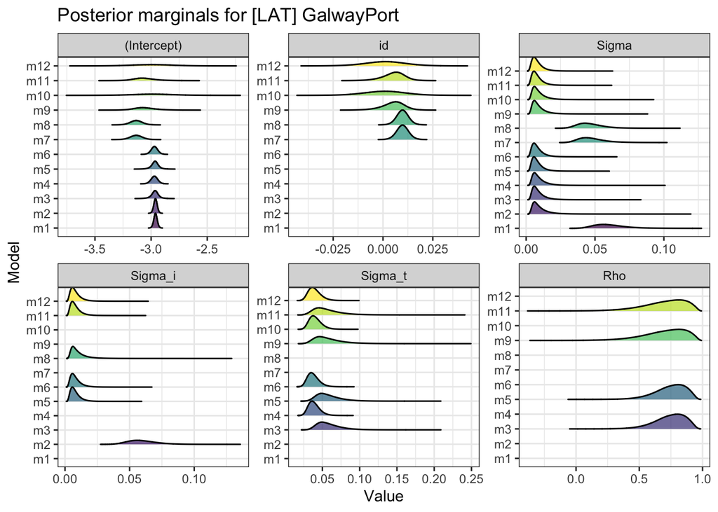

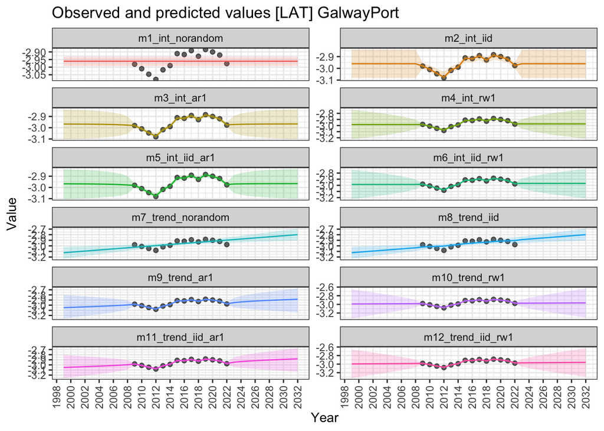

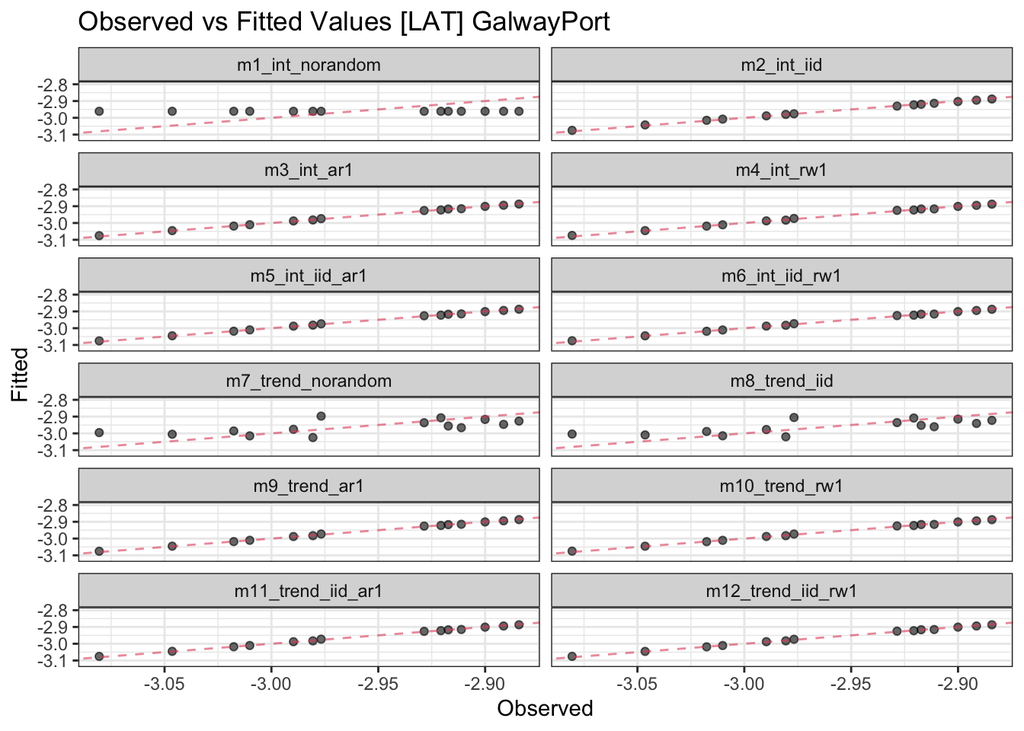

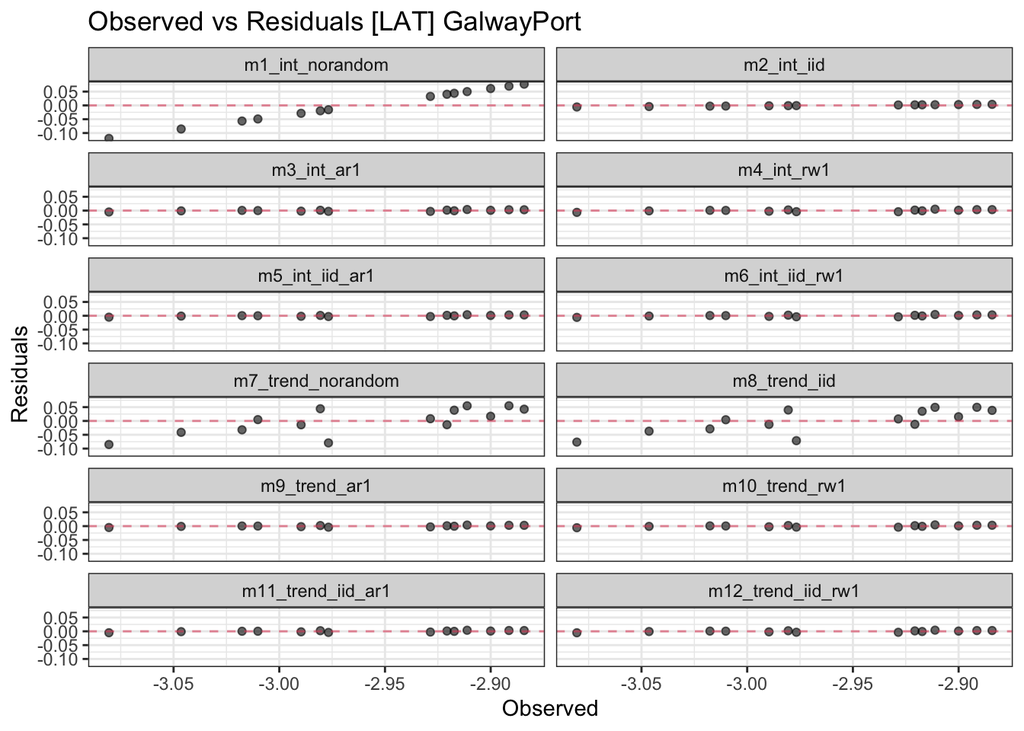

```r
show_temporal_results(
    "LAT",
    res,
    db
)
```